# Розділ 2 Модуль 1. Базовий. Лабораторна робота №1. Створення основи типового Data Science-проєкту

2023-01-15

[Daniil Tereshchenko](https://www.linkedin.com/in/daniil-tereshchenko/), 2023

### Задаємо параметри функції

```r
b0 <- 2
b1 <- 3
b2 <- 1.57
```

### Задаємо область визначення

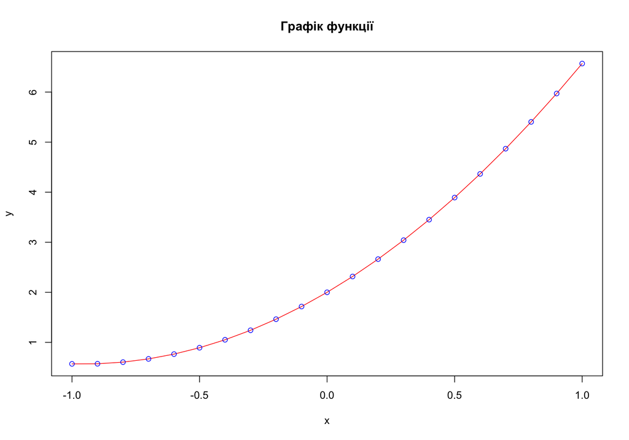

```r
x <- seq(-1, 1, .1)
y <- b0 + b1 * x + b2 * x^2

plot(x, y,
     type = "l",
     col = "red",
     main = "Графік функції",
     xlab = "x",
     ylab = "y"
     )
points(x, y,
       col = "blue")
```

### Cтворюємо дата-фрейм

```r
df <- data.frame(x = x, y = y)
```

## Інсталюємо та підключаємо пакет Rio

```r
# install.packages("rio")
library(rio)
```

### Виконуємо експорт дата-фрейму в файл csv

```r
export(df, "data/data.csv")
```

### Виконуємо імпорт дата-фрейму із файлу csv

```r
dfNew <-  import("data/data.csv")
```

## Таблиця засобами knitr

```r
knitr::kable(head(dfNew),
             caption = "_Табл. 1. Фрагмент таблиці даних_")
```

*Табл. 1. Фрагмент таблиці даних*

| x | y |
| --- | --- |
| -1.0 | 0.5700 |
| -0.9 | 0.5717 |
| -0.8 | 0.6048 |
| -0.7 | 0.6693 |
| -0.6 | 0.7652 |
| -0.5 | 0.8925 |

## Інсталюємо та підключаємо пакет stargazer

```r
# install.packages("stargazer")
library(stargazer)
```

### Таблиця засобами stargazer

```r
stargazer(head(dfNew),
                     type = "html",
                     summary = FALSE,
                     out="lb1_stargazer.html",
                     out.header=TRUE,
             title = "_Табл. 1. Фрагмент таблиці даних_")
```

**1. Фрагмент таблиці даних**

|  | x | y |
| --- | --- | --- |
| 1 | -1 | 0.570 |
| 2 | -0.900 | 0.572 |
| 3 | -0.800 | 0.605 |
| 4 | -0.700 | 0.669 |
| 5 | -0.600 | 0.765 |
| 6 | -0.500 | 0.893 |

## Інсталюємо та підключаємо пакет xtable

```r
# install.packages("xtable")
library(xtable)
```

### Таблиця засобами xtable

```r
xtable(head(dfNew),
                     type = "latex",
                     html.table.attributes="border=0",
                     summary = FALSE,
             caption = "_Табл. 1. Фрагмент таблиці даних_")
```

```
## % latex table generated in R 4.2.1 by xtable 1.8-4 package
## % Sun Jan 15 19:03:26 2023
## \begin{table}[ht]
## \centering
## \begin{tabular}{rrr}
##   \hline
##  & x & y \\
##   \hline
## 1 & -1.00 & 0.57 \\
##   2 & -0.90 & 0.57 \\
##   3 & -0.80 & 0.60 \\
##   4 & -0.70 & 0.67 \\
##   5 & -0.60 & 0.77 \\
##   6 & -0.50 & 0.89 \\
##    \hline
## \end{tabular}
## \caption{_Табл. 1. Фрагмент таблиці даних_}
## \end{table}
```

## Результуюча таблиця

```r
df_res <- data.frame(
  x = c("b0", "b1","b2", "x1", "x2"),
  y = c(b0, b1, b2, x[1], x[length(x-1)])
)
knitr::kable(head(df_res),
  col.names = c('Параметр','Значення'),
  caption = "_Табл. 2. Результуюча таблиця_")
```

*Табл. 2. Результуюча таблиця*

| Параметр | Значення |
| --- | --- |
| b0 | 2.00 |
| b1 | 3.00 |
| b2 | 1.57 |
| x1 | -1.00 |
| x2 | 1.00 |

## ggplot2 - оптимізація коду та можливості пакету

### Інсталюємо та підключаємо пакет ggplot2

```r
#install.packages("ggplot2")
library(ggplot2)
```

### Графік функції засобами пакету ggplot2

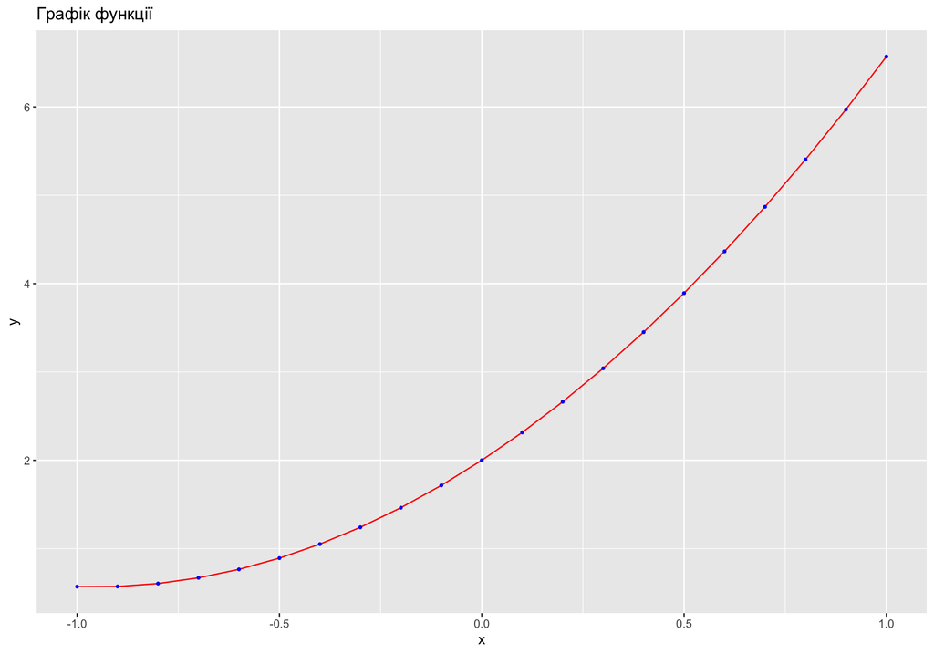

```r
ggplot(data = dfNew, aes(x = x, y = y)) +
    geom_line(color = "red") +
    geom_point(size = 0.75, color = "blue") +
    labs(title = "Графік функції")
```

## References

Allaire, JJ, Yihui Xie, Jonathan McPherson, Javier Luraschi, Kevin Ushey, Aron Atkins, Hadley Wickham, Joe Cheng, Winston Chang, and Richard Iannone. 2022. Rmarkdown: Dynamic Documents for r. https://CRAN.R-project.org/package=rmarkdown. Chan, Chung-hong, and Thomas J. Leeper. 2021. Rio: A Swiss-Army Knife for Data i/o. https://github.com/leeper/rio. Garrett Grolemund, Hadley Wickham. 2018. R for Data Science. http://r4ds.had.co.nz/index.html. R Core Team. 2022. R: A Language and Environment for Statistical Computing. Vienna, Austria: R Foundation for Statistical Computing. https://www.R-project.org/. RStudio Team. 2020. RStudio: Integrated Development Environment for r. Boston, MA: RStudio, PBC. http://www.rstudio.com/. sandino. 2013. “Cheat Sheet of Markdown.” Article. https://github.com/sandino/Markdown-Cheatsheet#emphasis. Wickham, Hadley. 2009. Ggplot2: Elegant Graphics for Data Analysis. Springer-Verlag New York. http://ggplot2.org. Wickham, Hadley, Winston Chang, Lionel Henry, Thomas Lin Pedersen, Kohske Takahashi, Claus Wilke, Kara Woo, Hiroaki Yutani, and Dewey Dunnington. 2021. Ggplot2: Create Elegant Data Visualisations Using the Grammar of Graphics. https://CRAN.R-project.org/package=ggplot2. wikipedia. 2018a. “Cross-Industry Standard Process for Data Mining.” Article. https://en.wikipedia.org/wiki/Cross-industry_standard_process_for_data_mining. Yihui Xie, Garrett Grolemund, J. J. Allaire. 2018. R Markdown: The Definitive Guide. https://bookdown.org/yihui/rmarkdown/.